# Differential Expression Analysis

Nguyen Huynh

2025-03-28

Abstract

After cell type annotation, we can run a couple of differential expression tests

### PART 1: Read in data

```r
# Set libPaths to global
.libPaths("/gpfs/fs1/sfw2/r/4.1.1/b1/lib64/R/library")
suppressPackageStartupMessages(library(Seurat))
suppressPackageStartupMessages(library(sctransform))
suppressPackageStartupMessages(library(ggplot2))
suppressPackageStartupMessages(library(dplyr))
suppressPackageStartupMessages(library(cowplot))
suppressPackageStartupMessages(library(ggthemes))
suppressPackageStartupMessages(library(knitr))
suppressPackageStartupMessages(library(clusterProfiler))
suppressPackageStartupMessages(library(GO.db))
suppressPackageStartupMessages(library(org.Mm.eg.db))
suppressPackageStartupMessages(library(fgsea))
suppressPackageStartupMessages(library(GeneOverlap))
suppressPackageStartupMessages(library(VennDiagram))
suppressPackageStartupMessages(library(jsonlite))
suppressPackageStartupMessages(library(GeneOverlap))
suppressPackageStartupMessages(library(glmnet))
suppressPackageStartupMessages(library(relaimpo))
suppressPackageStartupMessages(library(igraph))
```

```r
mouse_human_genes = read.csv("http://www.informatics.jax.org/downloads/reports/HOM_MouseHumanSequence.rpt",sep="\t")
```

```r
source("helper_data_wrangling_functions.R")
source("helper_plot_functions.R")
```

```r
integrated_object <- readRDS("outs/RDS/integrated_object.RDS")
```

```r
cellType_colors <- c("#FFFF00", "#FF00FF", economist_pal()(3), "#F15A60", "saddlebrown", "#FAA75B", "#9E67AB", "springgreen3", "blue", "grey80")
DefaultAssay(integrated_object) <- "RNA" # "RNA"
```

```r
markers <- list(msn = c("Ppp1r1b", "Drd1", "Drd2"),
                interneuron = c("Gad1", "Gad2", "Adarb2", "Lhx6", "Ache", "Pvalb"),
                gpc = c("Olig1", "Olig2", "Pdgfra", "Gpr17"),
                ol  = c("Plp1", "Mbp"),
                astrocyte = c("Aqp4", "Sox9"),
                microglia = c("Cx3cr1", "P2ry12"),
                pericyte = c("Pdgfrb", "Itga1"),
                corticalneuron = c("Slc17a7", "Tle4"))
```

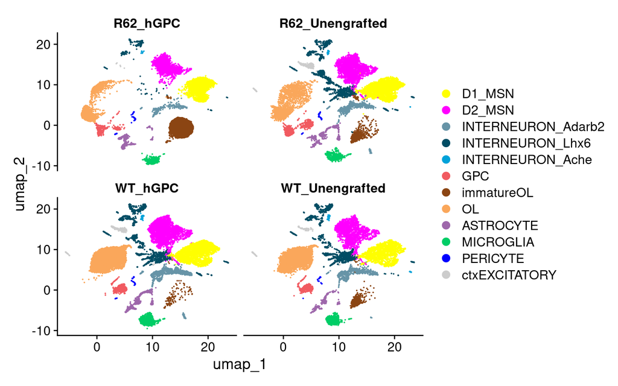

```r
DimPlot(integrated_object, cols = cellType_colors, ncol = 2, split.by = "mouse_engraft")
```

### PART 2: Differential expression

Pairwise differential expression analysis for MSN cell types

```r
source("05_getDiff_msn.R")
```

### PART 3: Focusing on the MSN DEG

```r
markers_msn_pair <- readRDS("outs/RDS/MAST_MSN_pairwise.RDS")
```

```r
markers_msn_rw_un <- markers_msn_pair[["rw_un"]]
markers_msn_rw_un <- lapply(markers_msn_rw_un, function(x) x[["MAST"]])
```

#### A data frame tagged with log2FC and padj

```r
x_msn <- list()
# Down
x_msn[["d1_dn"]] <- markers_msn_pair[["rw_un"]][["D1_MSN"]][["MAST"]] %>% filter(avg_log2FC < -0.25 & p_val_adj < 1e-3) %>% row.names()
x_msn[["d2_dn"]] <- markers_msn_pair[["rw_un"]][["D2_MSN"]][["MAST"]] %>% filter(avg_log2FC < -0.25 & p_val_adj < 1e-3) %>% row.names()

# Up
x_msn[["d1_up"]]  <- markers_msn_pair[["rw_un"]][["D1_MSN"]][["MAST"]] %>% filter(avg_log2FC > 0.25 & p_val_adj < 1e-3) %>% row.names()
x_msn[["d2_up"]]  <- markers_msn_pair[["rw_un"]][["D2_MSN"]][["MAST"]] %>% filter(avg_log2FC > 0.25 & p_val_adj < 1e-3) %>% row.names()

# Check that the down-regulated genes are not in the up-regulated list as well
y1 <- unlist(x_msn[c("d1_dn", "d2_dn")]) %>% unique()
y2 <- unlist(x_msn[c("d1_up", "d2_up")]) %>% unique()
table(y2 %in% y1); table(y1 %in% y2)
```

```
##
## FALSE
##   795
```

```
##
## FALSE
##   528
```

```r
# saveRDS(x_msn, "outs/RDS/DEG_MSN.RDS")
```

Add in log2FC and padj values

```r
# The union of y1 and y2 are a compilation of genes that have padj < 1e-3 and log2FC > 0.25 in one of the two MSN populations.
deg.df <- data.frame(Gene = union(y1, y2), Dysregulated_SubCluster = NA)
for (d in c("D1_MSN", "D2_MSN")) {
  tmp.df <- markers_msn_pair[["rw_un"]][[d]][["MAST"]]
  tmp.df <- tmp.df[row.names(tmp.df) %in% deg.df$Gene,] %>% dplyr::select(avg_log2FC, p_val_adj) %>% tibble::rownames_to_column(var = "Gene")
  deg.df <- merge(deg.df, tmp.df, all = TRUE, by = "Gene")
}

colnames(deg.df) <- c("Gene", "Dysregulated_SubCluster", "D1_log2FC", "D1_padj", "D2_log2FC", "D2_padj")
```

Describe whether it was dysregulated in D1, D2, or both

```r
vplD <- venn.diagram(list(D1 = x_msn[["d1_dn"]], D2 = x_msn[["d2_dn"]]), filename = NULL)
vplU <- venn.diagram(list(D1 = x_msn[["d1_up"]], D2 = x_msn[["d2_up"]]), filename = NULL)
junks <- list.files(".", "VennDiagram")
file.remove(junks)
```

```
## [1] TRUE
```

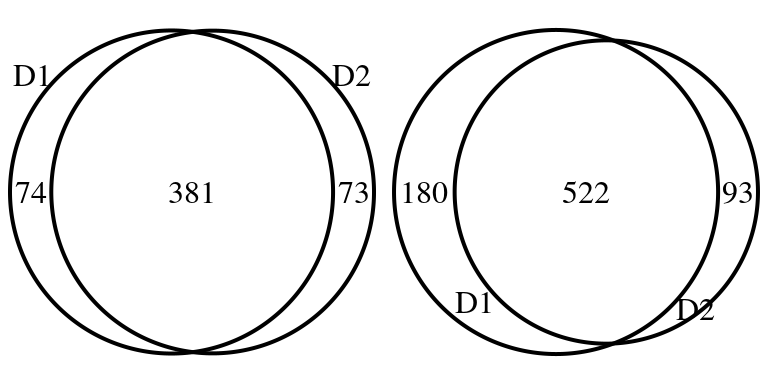

```r
plot_grid(vplD, vplU, ncol = 2)
```

```r
for (g in deg.df$Gene) {
  if (g %in% y1) { # if loop for down or up-regulated
    if (g %in% x_msn[["d1_dn"]] & !g %in% x_msn[["d2_dn"]]) {
      token <- "D1"
    } else if (!g %in% x_msn[["d1_dn"]] & g %in% x_msn[["d2_dn"]]) {
      token <- "D2"
    } else if (g %in% x_msn[["d1_dn"]] & g %in% x_msn[["d2_dn"]]) {
      token <- "Both"
    }
  } else if (g %in% y2) {
    if (g %in% x_msn[["d1_up"]] & !g %in% x_msn[["d2_up"]]) {
      token <- "D1"
    } else if (!g %in% x_msn[["d1_up"]] & g %in% x_msn[["d2_up"]]) {
      token <- "D2"
    } else if (g %in% x_msn[["d1_up"]] & g %in% x_msn[["d2_up"]]) {
      token <- "Both"
    }
  } # End big if loop for down or up regulated
  deg.df$Dysregulated_SubCluster[which(deg.df$Gene == g)] <- token
}

# write.table(deg.df, "outs/tables/DEG_MSN_rw_un.txt", sep = "\t", row.names = FALSE, col.names = TRUE, quote = FALSE)
```

#### Network analysis and cluster into gene communities with extensive pathways

##### Egos

y1 & y2 are genes that are dysregulated in either one or both MSNs

```r
source("05_egos.R")
```

The upregulated genes contribute to ribosome/translation ==> Dying cells. The downregulated genes overwhelmingly represent synapse-related pathways. It was not productive to try to cluster the GO terms, since it’s all synapse versus everybody else.

### PART 4: SynGO on downregulated genes

Since we observed that synaptic pathways were the most affected (re: downregulated genes), we would like to isolate out this effect and see if the downregulated synaptic functions are rescued upon engraftment.

```r
deg.df <- read.table("outs/tables/DEG_MSN_rw_un.txt", header = TRUE)
```

```r
goi <- deg.df$Gene[which(deg.df$D1_log2FC < -0.25 | deg.df$D2_log2FC < -0.25)]
# https://support.bioconductor.org/p/129636/
mouse_human_genes = read.csv("http://www.informatics.jax.org/downloads/reports/HOM_MouseHumanSequence.rpt",sep="\t")
goi <- convert_mouse_to_human(goi, mouse_human_genes)
# writeLines(goi, "outs/tables/MSN_downregulated_rw_un_forSynGO.txt") # 500 genes
```

Manually upload this gene list to synGO, then run the analysis with “brain-expressed” background, and save the SVG of BP, SVG of CC, as well as export data into a zipped folder.

```r
synGO <- readxl::read_excel("outs/tables/SynGO/Downregulated_R62_vs_WT_Baseline/SynGO_geneset_analysis__Downregulated_R62_vs_WT_Unengrafted/syngo_ontologies_with_annotations_matching_user_input.xlsx")
```

```r
# Sort by padj, remove CC and focus on BP
# Remove SYNGO terms because we don't know what the gene member is. Resort to GO ID for later comparisons in GSEA
synGO <- synGO[order(synGO$`GSEA 'gene cluster' FDR corrected p-value`),] %>% filter(`GO domain` == "BP" & `GSEA 'gene cluster' FDR corrected p-value` < 1e-3)
synGO <- synGO[startsWith(synGO$`GO term ID`, "GO"),] # 23 signif terms
# We can see that the first five really focus on synaptic signaling (H&I terms)
head(synGO)
```

```
## # A tibble: 6 × 14
##   `GO term ID` `user interface reference code` `GO domain` `GO term name`
##   <chr>        <chr>                           <chr>       <chr>
## 1 GO:0099536   H1                              BP          synaptic signaling
## 2 GO:0099537   H2                              BP          trans-synaptic signa…
## 3 GO:0050808   I1                              BP          synapse organization
## 4 GO:0007268   H12                             BP          chemical synaptic tr…
## 5 GO:0050804   H19                             BP          modulation of chemic…
## 6 GO:0007416   I10                             BP          synapse assembly
## # ℹ 10 more variables: `GO term name - hierarchical structure` <chr>,
## #   `GO parent term ID` <chr>, `GSEA p-value` <dbl>,
## #   `GSEA 'gene cluster' FDR corrected p-value` <dbl>,
## #   `GSEA count foreground/input` <dbl>, `GSEA count background` <dbl>,
## #   `genes - hgnc_id` <chr>, `genes - hgnc_symbol` <chr>,
## #   `genes - your genelist input` <chr>,
## #   `genes - without hierarchical rollup - hgnc_symbol` <chr>
```

```r
syngo_pIDs <- synGO$`GO term name`
pway_synGO.df <- relax_geneSet.f(gsea_df = synGO, geneset_colnames = "genes - hgnc_symbol", term_colnames = "GO term name", convert = "toMouse", delimiter = ";")
```

### PART 5: Recovery/Betterment of MSN upon hGPC transplantation

#### Dimensionality Reduction

Subset MSN and clustered with scVI/leiden on RNA

Output from 04_* scripts

```r
integrated_objectMSN <- readRDS("outs/RDS/integrated_objectMSN.RDS")
```

```r
DefaultAssay(integrated_objectMSN) <- "RNA"
```

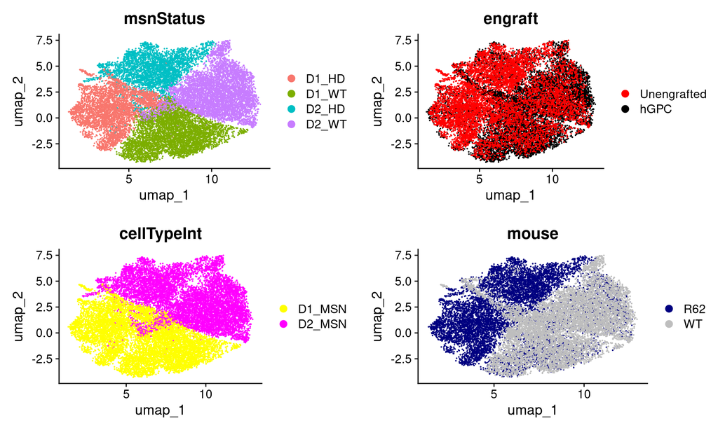

```r
p1 <- DimPlot(integrated_objectMSN, group.by = "msnStatus")
# We could see the segregation of MSNs... some perhaps affected by hGPC engraftment and some not?
p2 <- DimPlot(integrated_objectMSN, group.by = "cellTypeInt", cols = cellType_colors)
p3 <- DimPlot(integrated_objectMSN, group.by = "mouse", cols = c("navy", "grey"))
p4 <- DimPlot(integrated_objectMSN, group.by = "engraft", cols = c("red", "black"))

plot_grid(p1, p4, p2, p3, ncol = 2)
```

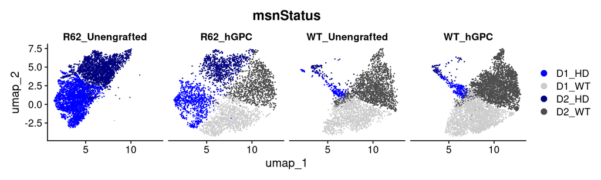

```r
DimPlot(integrated_objectMSN, group.by = "msnStatus", split.by = "mouse_engraft", cols = c("blue", "grey80", "navy", "grey30"))
```

Cell composition per cluster

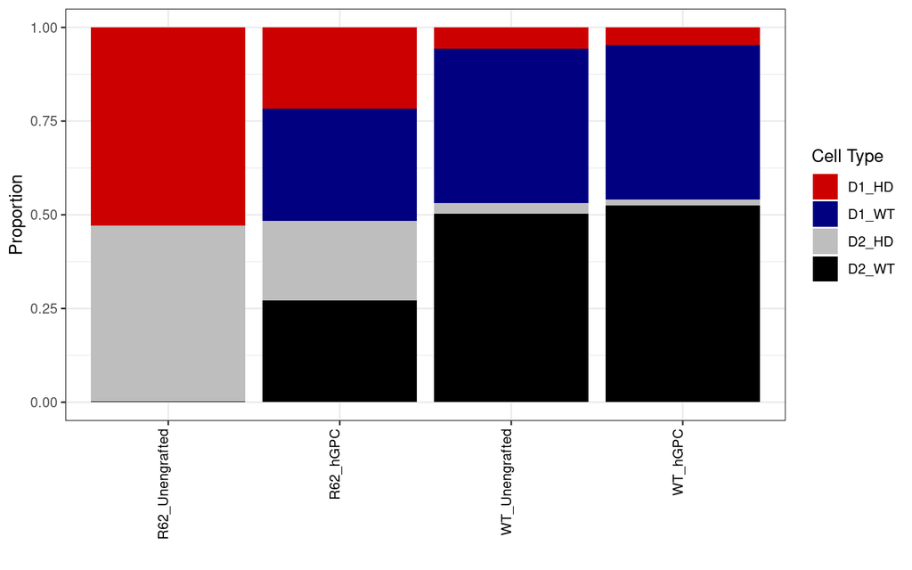

```r
cellType_counter <- integrated_objectMSN@meta.data[, c("mouse_engraft", "msnStatus")] %>% group_by(mouse_engraft, msnStatus) %>% count()
ggplot(cellType_counter, aes(x= mouse_engraft, y = n, fill = msnStatus)) + geom_bar(position = "fill", stat = "identity") + scale_fill_manual(values = c("red3", "navy", "grey", "black")) + theme_bw() + labs(x="", y = "Proportion", fill="Cell Type") + theme(axis.text.x = element_text(color = "black", angle = 90, hjust = 1, vjust = 0))
```

#### Differential Expression Analysis

Compare restored MSNs vs sick MSNs

```r
DefaultAssay(integrated_objectMSN) <- "RNA"
# Restore2 stores values of only R62+engraft that look like WT, and R62/unengraft that look sick and not like WT at all; and exclude all other cells
integrated_objectMSN <- SetIdent(integrated_objectMSN, value = "restore2")
subOb <- subset(integrated_objectMSN, subset = restore2 != "")
# Reset ident to restore, so that we can do diff by D1 and D2
subOb <- SetIdent(subOb, value = "restore")
restore_deg <- list()
for (ct in c("D1", "D2")) {
  restore_deg[[ct]] <- get_diff.f(object = subOb, ident1 = paste0(ct, "_restore"), ident2 = paste0(ct, "_sick"), fc_cut = 0.5, padj_cut = 1e-3)
}
saveRDS(restore_deg, "outs/RDS/MAST_R62MSN_restore.RDS")
```

### PART 6: Restoration on the pathway level

#### SynGO

What is upregulated in R62/engraft/healthy vs R62/noengraft/sick?

```r
restore_deg <- readRDS("outs/RDS/MAST_R62MSN_restore.RDS")
```

```r
# upregulated
syn_goi <- lapply(restore_deg, function(x) row.names(x$MAST)[x$MAST$avg_log2FC > 0.25 & x$MAST$p_val_adj < 1e-3])
syn_goi <- Reduce(union, unlist(syn_goi))
syn_goi <- convert_mouse_to_human(syn_goi, mouse_human_genes)
syn_goi <- unique(syn_goi)
# writeLines(syn_goi, "outs/tables/MSN_restoreUp_R62MSN_forSynGO.txt")
```

#### SynGO indicates that synapse organization is upregulated in the MSNs in restored compared to sick.

```r
synR_up <- readxl::read_excel("outs/tables/SynGO/RestoreUp_R62_hGPC_vs_Unengrafted/SynGO_geneset_analysis__RestoreUp_R62_hGPC_vs_Unengrafted/syngo_ontologies_with_annotations_matching_user_input.xlsx")
```

```r
# Sort by padj, remove CC and focus on BP
# Remove SYNGO terms because we don't know what the gene member is. Resort to GO ID for later comparisons in GSEA
# Go strict for top genes
synR_up <- synR_up[order(synR_up$`GSEA 'gene cluster' FDR corrected p-value`),] %>% filter(`GO domain` == "BP" & `GSEA 'gene cluster' FDR corrected p-value` < 1e-10)
synR_up <- synR_up[startsWith(synR_up$`GO term ID`, "GO"),] # 1 terms @ 1e-10
```

```r
synR_up # I
```

```
## # A tibble: 1 × 14
##   `GO term ID` `user interface reference code` `GO domain` `GO term name`
##   <chr>        <chr>                           <chr>       <chr>
## 1 GO:0050808   I1                              BP          synapse organization
## # ℹ 10 more variables: `GO term name - hierarchical structure` <chr>,
## #   `GO parent term ID` <chr>, `GSEA p-value` <dbl>,
## #   `GSEA 'gene cluster' FDR corrected p-value` <dbl>,
## #   `GSEA count foreground/input` <dbl>, `GSEA count background` <dbl>,
## #   `genes - hgnc_id` <chr>, `genes - hgnc_symbol` <chr>,
## #   `genes - your genelist input` <chr>,
## #   `genes - without hierarchical rollup - hgnc_symbol` <chr>
```

### PART 7: IMPORTANT TF CANDIDATES

#### Load precomputed pySCENIC results

```r
regs <- read_json("/path/to/pySCENIC/results/regulonsTarget.json", simplifyVector = T) # TF to target pairs
weight <- read_json("/path/to/pySCENIC/results/regulonsWeight.json", simplifyVector = T) # TF to gene2weight based on target order
names(regs) <- gsub("\\(.*", "", names(regs))
names(weight) <- gsub("\\(.*", "", names(weight))
```

```r
auc <- read.csv("/path/to/pySCENIC/results/auc.txt", stringsAsFactors = FALSE, row.names = 1)
colnames(auc) <- gsub("\\..*", "", colnames(auc))
```

#### Fisher enrichment test

What are the transcription factors upstream of targets that are enriched in SynGO terms? Perform this test for all TFs found in regs

```r
### Regulons against selected GO terms
synGO_list <- list(Baseline = readxl::read_excel("outs/tables/SynGO/Downregulated_R62_vs_WT_Baseline/SynGO_geneset_analysis__Downregulated_R62_vs_WT_Unengrafted/syngo_ontologies_with_annotations_matching_user_input.xlsx"),
                   Restore = readxl::read_excel("outs/tables/SynGO/RestoreUp_R62_hGPC_vs_Unengrafted/SynGO_geneset_analysis__RestoreUp_R62_hGPC_vs_Unengrafted/syngo_ontologies_with_annotations_matching_user_input.xlsx"))
synGO_list <- lapply(synGO_list, function(x) x %>% filter(`GO domain` == "BP" & `GSEA 'gene cluster' FDR corrected p-value` < 1e-3))
synGO_list <- lapply(synGO_list, function(x) x[startsWith(x$`GO term ID`, "GO"),])

picked_go <- unlist(lapply(synGO_list, function(x) x$`GO term ID`)) %>% unique()
picked_go <- picked_go[picked_go != "GO:0150052"]
allegs <- sapply(picked_go, function(x) get(x, org.Mm.egGO2ALLEGS))
picked_go_genes <- lapply(allegs, function(x) unlist(mget(x, org.Mm.egSYMBOL)))
fisherRes_syn <- data.frame(TF = character(), GO = character(), pval = numeric())
for (tf in names(regs)) {
  for (goid in names(picked_go_genes)) {
    goObj <- newGeneOverlap(regs[[tf]], picked_go_genes[[goid]], spec = "mm9.gene") # Number of genes annotated
    goObj <- testGeneOverlap(goObj)
    tmp <- data.frame(TF = tf, GO = goid, pval = goObj@pval)
    fisherRes_syn <- rbind(tmp, fisherRes_syn)
  }
}
# Adjust for multiple comparisons
fisherRes_syn$padj <- p.adjust(fisherRes_syn$pval, method = "BH")
# Map to GO names
tmp <- data.frame(ID = lapply(synGO_list, function(x) x$`GO term ID`) %>% unlist(),
                  Name = lapply(synGO_list, function(x) x$`GO term name`) %>% unlist())
tmp <- tmp[!duplicated(tmp), ]
fisherRes_syn$Term <- plyr::mapvalues(fisherRes_syn$GO, tmp$ID, tmp$Name)
```

#### Mean Activity by msnStatus

```r
names(regs)[names(regs) == "Nkx2-2"] <- "Nkx2"
names(regs)[names(regs) == "Nkx6-2"] <- "Nkx6"
meanAUC <- AverageExpression(integrated_objectMSN, assays = "AUC", features = names(regs), group.by = "restore2")$AUC
meanAUC <- as.data.frame(meanAUC)
```

#### Logistic regression to pull out important TFs

Find transcription factors that are loaded for baseline & restore

```r
# integrated_objectMSN <- readRDS("outs/RDS/integrated_objectMSN.RDS")
subOb <- subset(integrated_objectMSN, subset = restore2 != "")
auc_sub <- auc[row.names(subOb@meta.data),]
all.equal(row.names(auc_sub), row.names(subOb@meta.data))
success_record <- ifelse(subOb$restore2 =="restore", 1, 0)
set.seed(2358)
cv.lasso <- cv.glmnet(x=as.matrix(auc_sub), y = success_record, alpha = 1, family = "binomial")
model <- glmnet(x = as.matrix(auc_sub), y = success_record, alpha = 1, family = "binomial", lambda = cv.lasso$lambda.min)
coef <- as.data.frame(as.matrix(coef(model)))
coef <- tibble::rownames_to_column(coef, var = "TF")
gc()
# write.csv(coef, "outs/tables/LASSO_res.csv", quote = FALSE)
```

#### PickedTF

```r
coef <- read.csv("outs/tables/LASSO_res.csv", stringsAsFactors = FALSE, row.names = 1)
# TF of interest will have the following criteria:
## Positive coef: Meaning that higher activity means winning/restoring:
coef_filt <- coef[coef$s0 > 12,]
## Higher mean AUC in restore compared to baseline
mean_activity_restoreHigh <- row.names(meanAUC)[which((meanAUC$restore > meanAUC$baseline) & (meanAUC$restore > 0.05))]
## Their targets are enriched in SynGO terms
enriched_fisher <- fisherRes_syn$TF[fisherRes_syn$padj < 5e-2]
## These TFs are:
#### 1. Have a positive lasso score ( upregulated in restore)
#### 2. Higher mean activity in restore vs baseline
#### 3. Their targets are enriched for synapse-related pathways
#### 4. Their mean activity is higher than an arbitrary cutoff of 0.05. We reason that lower than that, the activity is not reliable
# Histogram shows that the first bin is 0.05
coef_filt <- coef_filt[coef_filt$TF %in% intersect(enriched_fisher, mean_activity_restoreHigh),]

# TF of interest
pickedTF <- coef_filt$TF
```

```r
# Remove TF whose expressions were not significantly restored upon engraftment
restore_deg <- readRDS("outs/RDS/MAST_R62MSN_restore.RDS")
x <- lapply(restore_deg, function(x) row.names(x$MAST)[which(x$MAST$avg_log2FC > 0.25 & x$MAST$p_val_adj < 1e-3)])
restore <- Reduce(intersect, x)
pickedTF <- pickedTF[pickedTF %in% unique(c(restore))]
# write.table(coef_filt[coef_filt$TF %in% pickedTF,], "outs/tables/pickedTF.txt", quote = FALSE)
```

```r
pickedTF
```

```
## [1] "Cux1"     "Esrrg"    "Ppargc1a" "Tcf7l1"
```

```r
# Since Tcf7l1 is an inhibitor, we remove it from the list
# as pySCENIC looks for activators only
# participates in the Wnt signaling pathway. Binds to DNA and acts as a repressor in the absence of CTNNB1, and as an activator in its presence.
pickedTF <- pickedTF[!pickedTF %in% "Tcf7l1"]

pickedTF
```

```
## [1] "Cux1"     "Esrrg"    "Ppargc1a"
```

```r
# writeLines(pickedTF, "outs/tables/pickedTF_list.txt")
```

### PART 8 : Contribution of background (WT vs R62) versus engraftment (with or without GPC)

```r
# integrated_objectMSN <- readRDS("integrated_objectMSN.RDS")
auc <- read.csv("/path/to/pySCENIC/results/auc.txt", stringsAsFactors = FALSE, row.names = 1)
colnames(auc) <- gsub("\\..*", "", colnames(auc))
```

```r
auc_sub <- auc[colnames(integrated_objectMSN), ]
all.equal(row.names(auc_sub), row.names(integrated_objectMSN@meta.data))
```

```
## [1] TRUE
```

```r
# Matrix to test for multicolinearity
tmp_mat <- data.frame(AUC = auc_sub[,1], background = integrated_objectMSN$mouse, engraft = integrated_objectMSN$engraft)
tmp_mod <- lm(AUC ~ background + engraft, data = tmp_mat)
# VIF < 5 so all good to go
car::vif(tmp_mod)
```

```
## background    engraft
##   1.038305   1.038305
```

```r
# Build a model where AUC is explained by the additive effect of both background and engraftment
magic_number <- length(pickedTF)
rsq  <- data.frame(row.names = pickedTF, R2=rep(0, magic_number), pval = rep(NA, magic_number))
proR <- data.frame(matrix(ncol=5, nrow=0))
colnames(proR) <- c("confidence", "lower", "upper", "covariate", "TF")
for (i in 1:magic_number) {
  me_name <- pickedTF[i]
  me <- auc_sub[, me_name]
  data_for_lm <- data.frame(AUC = me, background = as.factor(integrated_objectMSN$mouse), engraft = as.factor(integrated_objectMSN$engraft))
  fit <- lm(AUC ~ background + engraft, data = data_for_lm)
  # R-squared and p-val for the fit
  rsq[me_name, "R2"] <- summary(fit)$r.squared
  rsq[me_name, "pval"] <- lmp(fit)
  # Relaimpo
  cov_keep <- c("background", "engraft")
  tmp <- calculate_relative_importance(fit = fit, suffix = me_name)
  colnames(tmp) <- c("confidence", "lower", "upper", "covariate", "TF")
  proR <- rbind(proR, tmp)
}
# Adjust p-values for multiple comparisons
rsq$padj <- p.adjust(as.vector(rsq$pval), method = "BH")
```

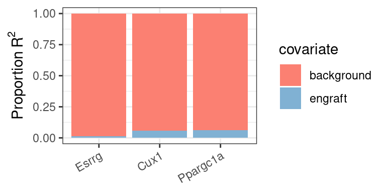

```r
# Rearrange proR by contribution to mouse, then set factor for ggplot
x <- proR %>% filter(covariate == "background")
x <- x[order(x$confidence, decreasing = TRUE),]
proR$TF <- factor(proR$TF, levels = x$TF)
col_pal <- RColorBrewer::brewer.pal(8, "Set3")[4:5]
#
p3 <- ggplot(proR, aes(x=TF, y=confidence, fill = covariate)) + geom_col() + scale_fill_manual(values = col_pal) + theme_bw() + theme(axis.text.x = element_text(angle = 30, hjust = 1), axis.title.x = element_blank()) + ylab(bquote('Proportion'~R^2))
p3
```

```r
# saveRDS(proR, "outs/RDS/proR.RDS")
```

### PART 9: The SYNGO network

#### SynGO genes

Retain ALL pickedTF candidates, but tried to see if they directly control any synaptic genes, or if they are upstream of a TF that is then upstream of synaptic genes

```r
# Restore: Upregulated in R62+GPC hanging out with WT vs R62_Unengrafted
synGO_list <- list(Baseline = readxl::read_excel("outs/tables/SynGO/Downregulated_R62_vs_WT_Baseline/SynGO_geneset_analysis__Downregulated_R62_vs_WT_Unengrafted/syngo_ontologies_with_annotations_matching_user_input.xlsx"),
                   Restore = readxl::read_excel("outs/tables/SynGO/RestoreUp_R62_hGPC_vs_Unengrafted/SynGO_geneset_analysis__RestoreUp_R62_hGPC_vs_Unengrafted/syngo_ontologies_with_annotations_matching_user_input.xlsx"))
synGO_list <- lapply(synGO_list, function(x) x %>% filter(`GO domain` == "BP" & `GSEA 'gene cluster' FDR corrected p-value` < 1e-3))
synGO_list <- lapply(synGO_list, function(x) x[startsWith(x$`GO term ID`, "GO"),])
```

```r
synGO_pway <- lapply(synGO_list, function(x) relax_geneSet.f(gsea_df = x, geneset_colnames = "genes - hgnc_symbol", term_colnames = "GO term name", convert = "toMouse", delimiter = ";"))
```

Some homologous genes might have passed through as we convert mouse to human symbols, and thus are there in the curated synGO list, but not signif. Remove these.

```r
baseline <- read.table("outs/tables/DEG_MSN_rw_un.txt", header = TRUE, stringsAsFactors = FALSE)
baseline1 <- baseline[(baseline$D1_log2FC < -0.25 & baseline$D1_padj < 1e-3), ]
baseline2 <- baseline[(baseline$D2_log2FC < -0.25 & baseline$D2_padj < 1e-3), ]
baseline <- intersect(baseline1$Gene, baseline2$Gene)

restore_deg <- readRDS("outs/RDS/MAST_R62MSN_restore.RDS")
restore <- lapply(restore_deg, function(x) row.names(x$MAST)[x$MAST$avg_log2FC > 0.25 & x$MAST$p_val_adj < 1e-3])
restore <- Reduce(intersect, restore)
```

```r
synGO_pway[[1]] <- synGO_pway[[1]][synGO_pway[[1]]$Gene %in% baseline,]
synGO_pway[[2]] <- synGO_pway[[2]][synGO_pway[[2]]$Gene %in% restore,]
```

Prune synGO_pway[[baseline]] to remove genes that were downregulated in R62 and baseline, and did not restore

```r
synGO_pway[["BaselinexRestore"]] = synGO_pway[["Baseline"]][synGO_pway[["Baseline"]]$Gene %in% restore, ]
```

```r
# The higher level terms
highLevel <- lapply(synGO_list, function(x) x[, c("user interface reference code", "GO term name")])
highLevel <- lapply(highLevel, function(x) {x$bigTerm <- substring(x$`user interface reference code`, 1,1); return(x)})
```

```r
highLevel$Baseline
```

```
## # A tibble: 23 × 3
##    `user interface reference code` `GO term name`                        bigTerm
##    <chr>                           <chr>                                 <chr>
##  1 F2                              regulation of presynaptic cytosolic … F
##  2 F13                             voltage-gated calcium channel activi… F
##  3 F21                             synaptic vesicle exocytosis           F
##  4 G2                              regulation of postsynaptic cytosolic… G
##  5 G4                              regulation of postsynaptic neurotran… G
##  6 G5                              regulation of postsynaptic membrane … G
##  7 G17                             neurotransmitter receptor localizati… G
##  8 G25                             regulation of neurotransmitter recep… G
##  9 G20                             postsynaptic neurotransmitter recept… G
## 10 G28                             regulation of postsynaptic neurotran… G
## # ℹ 13 more rows
```

```r
highLevel$Restore
```

```
## # A tibble: 11 × 3
##    `user interface reference code` `GO term name`                        bigTerm
##    <chr>                           <chr>                                 <chr>
##  1 F5                              synaptic vesicle cycle                F
##  2 F25                             synaptic vesicle endocytosis          F
##  3 G5                              regulation of postsynaptic membrane … G
##  4 H2                              trans-synaptic signaling              H
##  5 H12                             chemical synaptic transmission        H
##  6 H19                             modulation of chemical synaptic tran… H
##  7 I1                              synapse organization                  I
##  8 I4                              modification of synaptic structure    I
##  9 I19                             modification of postsynaptic structu… I
## 10 I10                             synapse assembly                      I
## 11 I26                             regulation of synapse assembly        I
```

```r
# save(highLevel, synGO_pway, file = "outs/RDS/MSN_restoreSynGO_diffRes.RData")
```

#### The picked TF networks

goi is the nodes where genes are restored with the tfs

```r
goi <- c(lapply(synGO_pway[c("Restore", "BaselinexRestore")], function(x) x$Gene) %>% unlist(), pickedTF) %>% unique()
```

```r
regs_pickedTF <- lapply(regs[pickedTF], function(x) x[x%in%goi])
regs_pickedTF.df <- data.frame(Gene = character(), Term = character())
for (i in names(regs_pickedTF)) {
  tmp <- data.frame(Gene = regs_pickedTF[[i]],
                    Term = rep(i, length(regs_pickedTF[[i]])))
  regs_pickedTF.df <- rbind(regs_pickedTF.df, tmp)
}
```

```r
highLevel.df <- purrr::reduce(highLevel, rbind)
highLevel.df <- highLevel.df[!duplicated(highLevel.df),]
highLevel.df
```

```
## # A tibble: 26 × 3
##    `user interface reference code` `GO term name`                        bigTerm
##    <chr>                           <chr>                                 <chr>
##  1 F2                              regulation of presynaptic cytosolic … F
##  2 F13                             voltage-gated calcium channel activi… F
##  3 F21                             synaptic vesicle exocytosis           F
##  4 G2                              regulation of postsynaptic cytosolic… G
##  5 G4                              regulation of postsynaptic neurotran… G
##  6 G5                              regulation of postsynaptic membrane … G
##  7 G17                             neurotransmitter receptor localizati… G
##  8 G25                             regulation of neurotransmitter recep… G
##  9 G20                             postsynaptic neurotransmitter recept… G
## 10 G28                             regulation of postsynaptic neurotran… G
## # ℹ 16 more rows
```

```r
# Read in restore and baseline deg
restore_deg <- readRDS("outs/RDS/MAST_R62MSN_restore.RDS")
restore_mast <- lapply(restore_deg, function(x) x$MAST)
restore_up <- lapply(restore_mast, function(x) row.names(x)[x$p_val_adj < 1e-3 & x$avg_log2FC > 0.25]) %>% unlist %>% unique() # > 0.25 for up # 7,187 genes

baseline_deg <- readRDS("outs/RDS/MAST_MSN_pairwise.RDS")[["rw_un"]]
baseline_mast <- lapply(baseline_deg, function(x) x$MAST)
baseline_down <- lapply(baseline_mast, function(x) row.names(x)[x$avg_log2FC < 0]) %>% unlist() %>% unique() # > 0.25 for up # 3,402 genes

# SynGO in restore that are differentially expressed
syngo_restore <- synGO_pway$Restore
# Prune for TF targets that are SIGNIFICANTLY up in restore and TRENDING down in baseline
syngo_restore_filt <- syngo_restore[syngo_restore$Gene %in% restore_up[restore_up %in% baseline_down],]
regs_pickedTF.df <- data.frame(Gene = character(), Term = character())
for (i in pickedTF) {
  targets_of_TF_filt <- regs[[i]][regs[[i]] %in% syngo_restore_filt$Gene]
  tmp <- data.frame(Gene = targets_of_TF_filt,
                    Term = rep(i, length(targets_of_TF_filt)))
  regs_pickedTF.df <- rbind(regs_pickedTF.df, tmp)
}
lapply(regs[pickedTF], function(x) length(x[x %in% syngo_restore_filt$Gene]))
```

```
## $Cux1
## [1] 22
##
## $Esrrg
## [1] 15
##
## $Ppargc1a
## [1] 19
```

```r
dim(regs_pickedTF.df) # SHould sum up to all the lengths above # 56
```

```
## [1] 56  2
```

#### EDGE

```r
# Map smaller terms to bigger terms
synGO_pway2 <- syngo_restore_filt
synGO_pway2$Term <- plyr::mapvalues(synGO_pway2$Term, highLevel.df$`GO term name`, highLevel.df$bigTerm, warn_missing = FALSE)
# Remove genes that are not targets of the picked TFs
synGO_pway2 <- synGO_pway2[which(synGO_pway2$Gene %in% unique(regs_pickedTF.df$Gene)),]
synGO_pway2 <- synGO_pway2[!duplicated(synGO_pway2),]
# Stitch the to TF
synGO_pway2 <- rbind(synGO_pway2, regs_pickedTF.df)
row.names(synGO_pway2) <- NULL
# Add in type
edge.df <- synGO_pway2
edge.df$type <- ifelse(nchar(edge.df$Term) == 1, "GO", "TF")
```

#### NODE

```r
node1 <- data.frame(Node = unique(c(edge.df$Gene, pickedTF)))
for (msn in c("D1", "D2")) {
  x_restore <- restore_mast[[msn]][, c("avg_log2FC", "p_val_adj")] %>% tibble::rownames_to_column(var = "Gene")
  colnames(x_restore) <- c("Gene", paste0(msn, "_log2FC_restore"), paste0(msn, "_padj_restore"))
  node1 <- merge(node1, x_restore, by.x = "Node", by.y = "Gene")

  x_baseline <- baseline_mast[[paste0(msn, "_MSN")]][, c("avg_log2FC", "p_val_adj")] %>% tibble::rownames_to_column(var = "Gene")
  colnames(x_baseline) <- c("Gene", paste0(msn, "_log2FC_baseline"), paste0(msn, "_padj_baseline"))
  node1 <- merge(node1, x_baseline, by.x = "Node", by.y = "Gene")
}
# Type of node
node1$Type <- ifelse(node1$Node %in% pickedTF, "TF", "Gene")
# Add in Term and TF info
node2 <- data.frame(Node = unique(edge.df$Term))
node2 <- node2[!node2$Node %in% pickedTF,, drop = FALSE]
node2$Type <- "Term"
node.df <- dplyr::bind_rows(node1, node2)
```

#### NETWORK

```r
edge <- edge.df
node <- node.df

v <- edge[,1:2]
g <- graph_from_data_frame(v,directed = F)

node_type_order <- plyr::mapvalues(vertex_attr(g)$name, node$Node, node$Type)
node_shape <- plyr::mapvalues(node_type_order, c("Gene", "TF", "Term"), c("circle", "sphere", "square"))
node_size <- plyr::mapvalues(node_type_order, c("Gene", "TF", "Term"), c(15, 20, 20)) %>% as.numeric()
vertex_attr(g)$name[which(nchar(vertex_attr(g)$name) == 1)]
```

```
## [1] "F" "G" "H" "I"
```

```r
which(nchar(vertex_attr(g)$name) == 1)
```

```
## [1] 48 49 50 51
```

```r
node_color <- plyr::mapvalues(node_type_order, c("Gene", "TF", "Term"), c("grey", "red", "blue"))
node_color[which(nchar(vertex_attr(g)$name) == 1)] <- c("blue", "greenyellow", "limegreen", "darkorchid")

edge_color <- plyr::mapvalues(edge$Term, c("Cux1", "Esrrg", "Ppargc1a", "F", "G", "H", "I"), c("grey", "grey", "grey", "blue", "greenyellow", "limegreen", "darkorchid"))
```

High levels:  
H: synaptic signaling;  
I: synapse organization,  
G: process in the postsynapse  
F: synaptic vesicle exocytosis

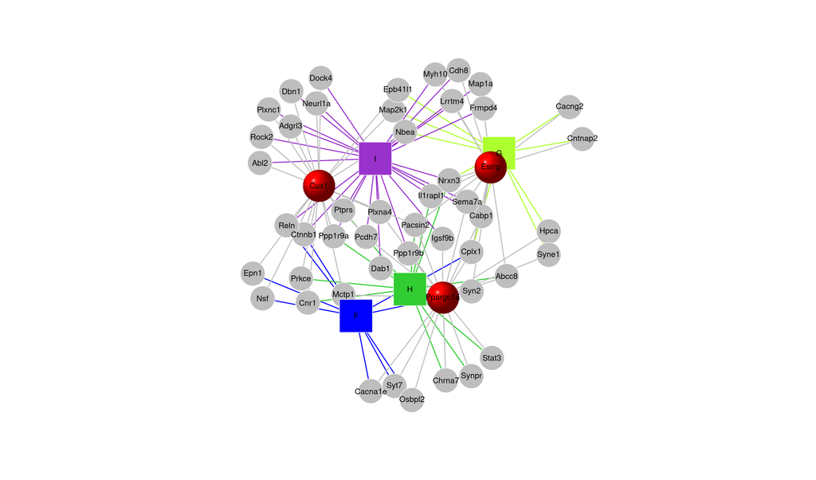

```r
plot(g, vertex.shape = node_shape, vertex.size = node_size, vertex.color = node_color, vertex.frame.color = "white", vertex.label.color = "black", vertex.label.size = 10, edge.color = edge_color, edge.width = 2, vertex.label.family = "Helvetica")
```